# Análise Citi Bike - Primeiro Trimestre 2017

Os dados utilizados para essa análise foram coletados a partir de viagens realizadas pelas bicicletas do Citi Bike na cidade de Nova York. Eles nos mostram inúmeras informações importantes sobre as viagens realizadas (duração, localização) e sobre os usuários que utilizam as bicicletas(gênero, idade, tipo de assinatura), a partir dos dados referentes ao primeiro trimestre de 2017 tentarei entender um pouco mais sobre quem são os usuários e as características de suas viagens.

```python
import pandas as pd #versão 0.25.1
import numpy as np #versão 1.16.5
import matplotlib.pyplot as plt #versão 3.1.1
import seaborn as sns #versão 0.9.0
import datetime
%matplotlib inline
import glob
import plotly.express as px #versão 4.1.0
```

```python
path = 'datasets'
all_files = glob.glob(path + "/*.csv")
li = []
for filename in all_files:
    df = pd.read_csv(filename, index_col=None, header=0)
    li.append(df)
df = pd.concat(li, axis=0, ignore_index=True)
```

# Limpeza e Modelagem de dados

Nessa parte, analisarei os tipos de dados de cada coluna, alterando-os caso necessário, se existem dados faltando e se é necessário a criação de colunas calculadas.

```python
#primeiras 5 linhas para ter uma ideia dos dados
df.head()
```

|  | Trip Duration | Start Time | Stop Time | Start Station ID | Start Station Name | Start Station Latitude | Start Station Longitude | End Station ID | End Station Name | End Station Latitude | End Station Longitude | Bike ID | User Type | Birth Year | Gender |
| --- | --- | --- | --- | --- | --- | --- | --- | --- | --- | --- | --- | --- | --- | --- | --- |
| 0 | 680 | 2017-01-01 00:00:21 | 2017-01-01 00:11:41 | 3226 | W 82 St & Central Park West | 40.782750 | -73.971370 | 3165 | Central Park West & W 72 St | 40.775794 | -73.976206 | 25542 | Subscriber | 1965.0 | 2 |
| 1 | 1282 | 2017-01-01 00:00:45 | 2017-01-01 00:22:08 | 3263 | Cooper Square & E 7 St | 40.729236 | -73.990868 | 498 | Broadway & W 32 St | 40.748549 | -73.988084 | 21136 | Subscriber | 1987.0 | 2 |
| 2 | 648 | 2017-01-01 00:00:57 | 2017-01-01 00:11:46 | 3143 | 5 Ave & E 78 St | 40.776829 | -73.963888 | 3152 | 3 Ave & E 71 St | 40.768737 | -73.961199 | 18147 | Customer | NaN | 0 |
| 3 | 631 | 2017-01-01 00:01:10 | 2017-01-01 00:11:42 | 3143 | 5 Ave & E 78 St | 40.776829 | -73.963888 | 3152 | 3 Ave & E 71 St | 40.768737 | -73.961199 | 21211 | Customer | NaN | 0 |
| 4 | 621 | 2017-01-01 00:01:25 | 2017-01-01 00:11:47 | 3143 | 5 Ave & E 78 St | 40.776829 | -73.963888 | 3152 | 3 Ave & E 71 St | 40.768737 | -73.961199 | 26819 | Customer | NaN | 0 |

```python
#verificando se os tipos dos dados estão corretos
df.info()
```

```
<class 'pandas.core.frame.DataFrame'>
RangeIndex: 2245988 entries, 0 to 2245987
Data columns (total 15 columns):
Trip Duration              int64
Start Time                 object
Stop Time                  object
Start Station ID           int64
Start Station Name         object
Start Station Latitude     float64
Start Station Longitude    float64
End Station ID             int64
End Station Name           object
End Station Latitude       float64
End Station Longitude      float64
Bike ID                    int64
User Type                  object
Birth Year                 float64
Gender                     int64
dtypes: float64(5), int64(5), object(5)
memory usage: 257.0+ MB
```

Transformarei as datas para datetime e o genêro para texto (de acordo com o enum disponibilizado pelo site).

```python
df['Start Time'] = pd.to_datetime(df['Start Time'])
df['Stop Time'] = pd.to_datetime(df['Stop Time'])
df.loc[df.Gender == 1,'Gender'] = 'Masculino'
df.loc[df.Gender == 2,'Gender'] = 'Feminino'
df.loc[df.Gender == 0,'Gender'] = 'Desconhecido'
```

```python
print('Tipo da coluna de Gender:' ,df['Gender'].dtype)
print('Tipos das colunas de Start e Stop time :' ,df['Start Time'].dtype,df['Stop Time'].dtype)
```

```
Tipo da coluna de Gender: object
Tipos das colunas de Start e Stop time : datetime64[ns] datetime64[ns]
```

```python
df.isna().sum()
```

```
Trip Duration                   0
Start Time                      0
Stop Time                       0
Start Station ID                0
Start Station Name              0
Start Station Latitude          0
Start Station Longitude         0
End Station ID                  0
End Station Name                0
End Station Latitude            0
End Station Longitude           0
Bike ID                         0
User Type                   15909
Birth Year                 111245
Gender                          0
dtype: int64
```

Apesar da grande quantidade de dados faltando para as colunas de Birth Year e User Type, os outros dados parecem estar integros, portanto deixarei da forma como está, pois mesmo que as informações sobre o usuário estejam faltando, as informações sobre a viagem ainda serão relevantes para essa análise.

```python
df.describe()
```

|  | Trip Duration | Start Station ID | Start Station Latitude | Start Station Longitude | End Station ID | End Station Latitude | End Station Longitude | Bike ID | Birth Year |
| --- | --- | --- | --- | --- | --- | --- | --- | --- | --- |
| count | 2.245988e+06 | 2.245988e+06 | 2.245988e+06 | 2.245988e+06 | 2.245988e+06 | 2.245988e+06 | 2.245988e+06 | 2.245988e+06 | 2.134743e+06 |
| mean | 7.939895e+02 | 1.220871e+03 | 4.073700e+01 | -7.398510e+01 | 1.204352e+03 | 4.073667e+01 | -7.398525e+01 | 2.209790e+04 | 1.977496e+03 |
| std | 8.312495e+03 | 1.279914e+03 | 4.677363e-02 | 7.163852e-02 | 1.272356e+03 | 6.626700e-02 | 1.115583e-01 | 4.412650e+03 | 1.197984e+01 |
| min | 6.100000e+01 | 7.200000e+01 | 0.000000e+00 | -7.403137e+01 | 7.200000e+01 | 0.000000e+00 | -7.403853e+01 | 1.452900e+04 | 1.858000e+03 |
| 25% | 3.370000e+02 | 3.560000e+02 | 4.072066e+01 | -7.399595e+01 | 3.540000e+02 | 4.072037e+01 | -7.399601e+01 | 1.801100e+04 | 1.969000e+03 |
| 50% | 5.400000e+02 | 4.800000e+02 | 4.073902e+01 | -7.398752e+01 | 4.790000e+02 | 4.073902e+01 | -7.398765e+01 | 2.154900e+04 | 1.980000e+03 |
| 75% | 8.950000e+02 | 3.092000e+03 | 4.075500e+01 | -7.397669e+01 | 3.085000e+03 | 4.075467e+01 | -7.397704e+01 | 2.614100e+04 | 1.987000e+03 |
| max | 5.325688e+06 | 3.456000e+03 | 4.080421e+01 | 0.000000e+00 | 3.456000e+03 | 4.080421e+01 | 0.000000e+00 | 2.919600e+04 | 2.001000e+03 |

Percebi que na coluna de duração da viagem (Trip Duration) existem alguns valores que possivelmente são outliers (estão distantes da maioria portanto são atípicos), assim como na coluna de data de nascimento (Birth Year), para removê-los utilizarei o z-score (Escore padrão), mas manterei os valores nulos da coluna de Birth Year.

```python
#remove outliers trip duration
df = df[((df['Trip Duration'] - df['Trip Duration'].mean()) / df['Trip Duration'].std()).abs() < 3]
#remove outliers birth year mas mantem valores nulos
df = pd.concat([df[df['Birth Year'].isna()],df[((df['Birth Year'] - df['Birth Year'].mean()) / df['Birth Year'].std()).abs() < 3]])
df[['Trip Duration','Birth Year']].describe()
```

|  | Trip Duration | Birth Year |
| --- | --- | --- |
| count | 2.240160e+06 | 2.129329e+06 |
| mean | 7.157789e+02 | 1.977594e+03 |
| std | 7.059068e+02 | 1.177422e+01 |
| min | 6.100000e+01 | 1.942000e+03 |
| 25% | 3.370000e+02 | 1.969000e+03 |
| 50% | 5.400000e+02 | 1.980000e+03 |
| 75% | 8.940000e+02 | 1.987000e+03 |
| max | 2.570700e+04 | 2.001000e+03 |

```python
#cria um dataframe com as linhas para remoção
df_to_remove = df.loc[(df['Start Station Latitude'] == 0) |
                         (df['End Station Latitude'] == 0) |
                         (df['Start Station Longitude'] == 0) |
                         (df['End Station Longitude'] == 0) ]
print('Número de linhas com latitude e/ou longitude zero: ', df_to_remove.shape[0])
```

```
Número de linhas com latitude e/ou longitude zero:  4
```

A partir do valor mínimo percebe-se que existem linhas nas quais a latitude e longitude são zero, como elas influenciariam no resultado dessa análise, optei por removê-las.

```python
df.drop(df_to_remove.index,axis=0,inplace=True)
```

```python
df_to_remove = df.loc[(df['Start Station Latitude'] == 0) |
                         (df['End Station Latitude'] == 0) |
                         (df['Start Station Longitude'] == 0) |
                         (df['End Station Longitude'] == 0) ]
print('Número de linhas com latitude e/ou longitude zero: ', df_to_remove.shape[0])
```

```
Número de linhas com latitude e/ou longitude zero:  0
```

A partir da coluna Birth Year criarei uma coluna aproximada para a idade do usuário e outra coluna com a faixa etária a qual ele pertence. Criarei outras colunas para a duração da viagem em minutos, hora de início e fim, mês, dia da semana e a rota da viagem.

```python
df['Age'] = 2017-df['Birth Year']
#cria uma coluna calculada com a faixa etária a partir da coluna de idade ('Age')
df['AgeRange'] = pd.cut(df['Age'], [10, 20, 30,40,50,60,70,80],labels=['10-20', '20-30', '30-40', '40-50', '50-60', '60-70', '70-80',])
#duração da viagem em minutos
df['Trip Duration Minutes'] = df['Trip Duration'] / 60
#hora de início
df['Start Hour'] = df['Start Time'].dt.hour
#hora de parada
df['Stop Hour'] = df['Stop Time'].dt.hour
#mês
df['Month'] = df['Start Time'].dt.month
#dia da semana
df['Weekday'] = df['Start Time'].dt.dayofweek
#rota
df['Route'] = df['Start Station Name'] + " -> " + df['End Station Name']
```

```python
#última olhada no dados antes de começar a análise
df.head()
```

|  | Trip Duration | Start Time | Stop Time | Start Station ID | Start Station Name | Start Station Latitude | Start Station Longitude | End Station ID | End Station Name | End Station Latitude | ... | Birth Year | Gender | Age | AgeRange | Trip Duration Minutes | Start Hour | Stop Hour | Month | Weekday | Route |
| --- | --- | --- | --- | --- | --- | --- | --- | --- | --- | --- | --- | --- | --- | --- | --- | --- | --- | --- | --- | --- | --- |
| 2 | 648 | 2017-01-01 00:00:57 | 2017-01-01 00:11:46 | 3143 | 5 Ave & E 78 St | 40.776829 | -73.963888 | 3152 | 3 Ave & E 71 St | 40.768737 | ... | NaN | Desconhecido | NaN | NaN | 10.800000 | 0 | 0 | 1 | 6 | 5 Ave & E 78 St -> 3 Ave & E 71 St |
| 3 | 631 | 2017-01-01 00:01:10 | 2017-01-01 00:11:42 | 3143 | 5 Ave & E 78 St | 40.776829 | -73.963888 | 3152 | 3 Ave & E 71 St | 40.768737 | ... | NaN | Desconhecido | NaN | NaN | 10.516667 | 0 | 0 | 1 | 6 | 5 Ave & E 78 St -> 3 Ave & E 71 St |
| 4 | 621 | 2017-01-01 00:01:25 | 2017-01-01 00:11:47 | 3143 | 5 Ave & E 78 St | 40.776829 | -73.963888 | 3152 | 3 Ave & E 71 St | 40.768737 | ... | NaN | Desconhecido | NaN | NaN | 10.350000 | 0 | 0 | 1 | 6 | 5 Ave & E 78 St -> 3 Ave & E 71 St |
| 18 | 759 | 2017-01-01 00:09:30 | 2017-01-01 00:22:09 | 267 | Broadway & W 36 St | 40.750977 | -73.987654 | 520 | W 52 St & 5 Ave | 40.759923 | ... | NaN | Desconhecido | NaN | NaN | 12.650000 | 0 | 0 | 1 | 6 | Broadway & W 36 St -> W 52 St & 5 Ave |
| 24 | 6370 | 2017-01-01 00:11:34 | 2017-01-01 01:57:44 | 449 | W 52 St & 9 Ave | 40.764618 | -73.987895 | 524 | W 43 St & 6 Ave | 40.755273 | ... | NaN | Desconhecido | NaN | NaN | 106.166667 | 0 | 1 | 1 | 6 | W 52 St & 9 Ave -> W 43 St & 6 Ave |

5 rows × 23 columns

Aqui finalizo a parte de limpeza e modelagem dos dados.

# Análise de perfil dos usuários

Nessa etapa, analisarei o perfil dos usuários que utilizam as bicicletas, em relação ao genêro, idade e tipo de assinatura.

```python
df_user_an = df.copy()
```

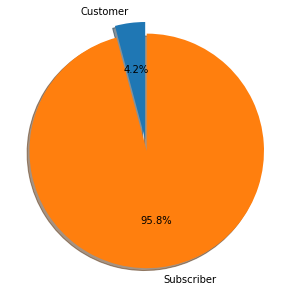

```python
labels = list(['Customer','Subscriber'])
sizes = pd.Series(df_user_an.groupby(('User Type')).size() / len(df_user_an) *100)
explode = (0.1, 0)
fig1, ax1 = plt.subplots(figsize=(5,5))
ax1.pie(sizes, explode=explode, labels=labels, autopct='%1.1f%%',
        shadow=True, startangle=90)
ax1.axis('equal')
plt.show()
```

Como visto no gráfico o percentual de assinantes anuais (Subscribers) é extremamente maior que o daqueles que compram passes de 24h ou 3 dias (Customers), o que pode nos sugerir uma fidelidade por parte dos usuários, ou seja, a maior parte deles utiliza o serviço constantemente e por esse motivo prefere a assinatura anual que é econômicamente mais viável.

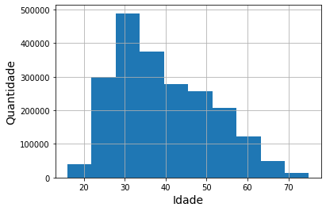

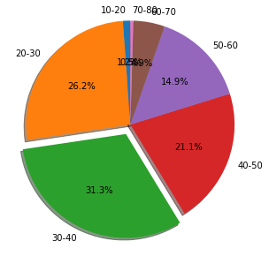

```python
df_user_an['Age'].hist()
plt.xlabel('Idade', fontsize=14)
plt.ylabel('Quantidade', fontsize=14)
plt.show()
labels = list(['10-20','20-30','30-40','40-50','50-60','60-70','70-80'])
sizes = pd.Series(df_user_an.groupby(('AgeRange')).size() / len(df_user_an) *100)
explode = (0, 0,0.1,0,0,0,0)
fig1, ax1 = plt.subplots(figsize=(5,5))
ax1.pie(sizes, explode=explode, labels=labels, autopct='%1.1f%%',
        shadow=True, startangle=90)
ax1.axis('equal')
plt.show()
```

A partir dos gráficos percebe-se que a faixa etária com maior número de usuários é dos 30 aos 40 anos com 31,3% dos usuários.

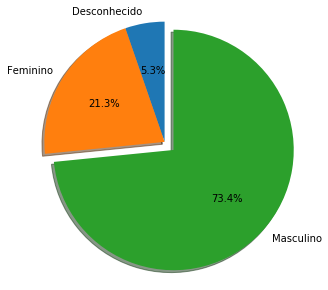

```python
labels = list(['Desconhecido','Feminino','Masculino'])
sizes = pd.Series(df_user_an.groupby(('Gender')).size() / len(df_user_an) *100)
explode = (0,0,0.1)
fig1, ax1 = plt.subplots(figsize=(5,5))
ax1.pie(sizes, explode=explode, labels=labels, autopct='%1.1f%%',
        shadow=True, startangle=90)
ax1.axis('equal')
plt.show()
```

Para finalizar a análise de perfil identifiquei que 73,4% dos usuários pertencem ao gênero masculino.

# Análise das viagens

Nessa etapa analisarei as viagens em relação a sua duração, trajeto e localização.

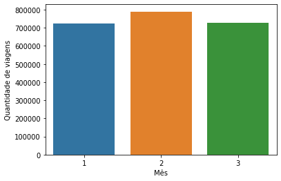

```python
sns.countplot(data=df,x='Month')
plt.ylabel('Quantidade de viagens')
plt.xlabel('Mês')
```

O mês com mais viagens do primeiro trimestre foi fevereiro, mas a quantidade variou pouco.

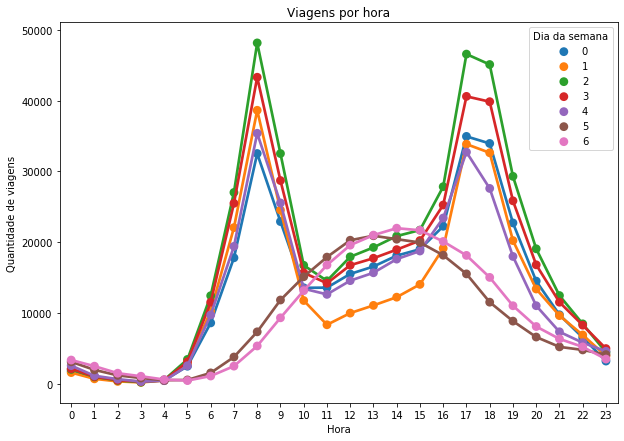

```python
series_y =df.groupby(['Start Hour','Weekday']).size().reset_index(name='count')
fig, ax = plt.subplots(figsize=(10,7))
sns.pointplot(ax=ax,data=series_y,x='Start Hour',y='count',hue='Weekday')
plt.xlabel('Hora')
plt.title('Viagens por hora')
plt.ylabel('Quantidade de viagens')
plt.legend(title='Dia da semana')
```

O gráfico (0 = Segunda-feira e 6 = Domingo) mostra dois pontos de pico de viagens durante os dias úteis da semana , o primeiro entre as 7 e 9 horas, e o segundo entre as 17 e 19 horas. Esses dois horários devem estar ligados aos horários de entrada e saída do trabalho, nos quais os usuários utilizam as bicicletas para ir e voltar. Já aos finais de semana os horários se alteram e a maior movimentação ocorre no fim da manhã e durante o período da tarde, o que nos sugere que a maior parte dos usuário utilizam as bicicletas para passeio aos finais de semana.

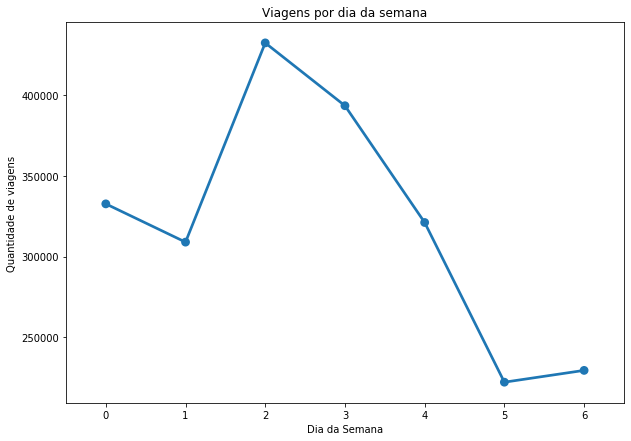

```python
week_days = df.groupby(['Weekday']).size().reset_index(name='count')
fig, ax = plt.subplots(figsize=(10,7))
sns.pointplot(data=week_days,x='Weekday',y='count')
plt.xlabel('Dia da Semana')
plt.title('Viagens por dia da semana')
plt.ylabel('Quantidade de viagens')
```

Percebe-se uma quantidade de viagens elevada durante os dias úteis da semana, e uma queda no fim de semana, o que nos sugere e fortalece a ideia de que a maior parte dos usuários utiliza as bicicletas como meio de transporte para o trabalho, escola, faculdade, etc.

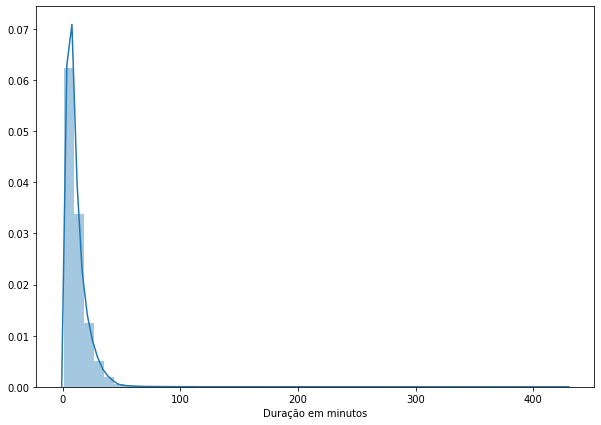

```python
fig, ax = plt.subplots(figsize=(10,7))
sns.distplot(df['Trip Duration Minutes'])
plt.xlabel('Duração em minutos')
```

Apesar de existirem algumas viagens com duração muito elevada, a maior parte possui menos de 100 minutos, portanto, filtrarei aquelas menores que 100 minutos para conseguir analisar melhor.

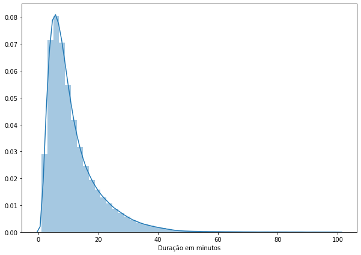

```
A média de duração das viagens é de  11.92958300671914  minutos.
```

```python
df_dur = df.loc[df['Trip Duration Minutes'] < 100]
fig, ax = plt.subplots(figsize=(10,7))
sns.distplot(df_dur['Trip Duration Minutes'])
plt.xlabel('Duração em minutos')
plt.show()
print('A média de duração das viagens é de ',df['Trip Duration Minutes'].mean(),' minutos.')
```

A partir da distruição percebe-se que a maior parte das viagens possui até 20 minutos de duração.

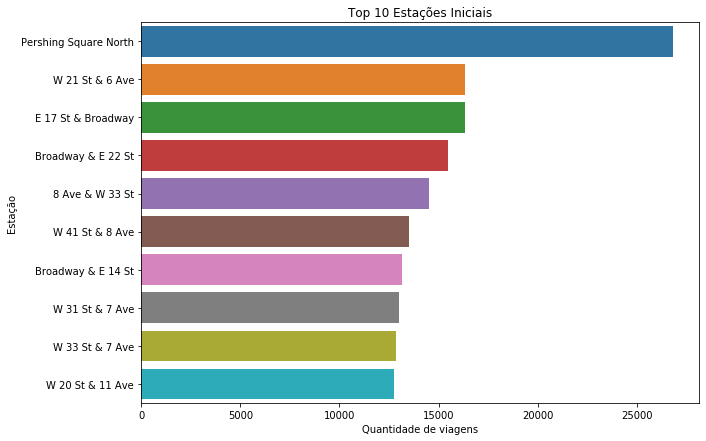

```
A estação menos utilizada para começar a viagem é a 67    8D OPS 01
Name: Start Station Name, dtype: object
```

```python
#verifica quais as estação mais populares para iniciar as viagens
start_station_top = df.groupby(['Start Station Name']).size().reset_index(name='count').sort_values(by='count',ascending=False)
fig, ax = plt.subplots(figsize=(10,7))
sns.barplot(data=start_station_top.head(10),y='Start Station Name',x='count')
plt.ylabel('Estação')
plt.xlabel('Quantidade de viagens')
plt.title('Top 10 Estações Iniciais')
plt.show()
print('A estação menos utilizada para começar a viagem é a',start_station_top.tail(1)['Start Station Name'])
```

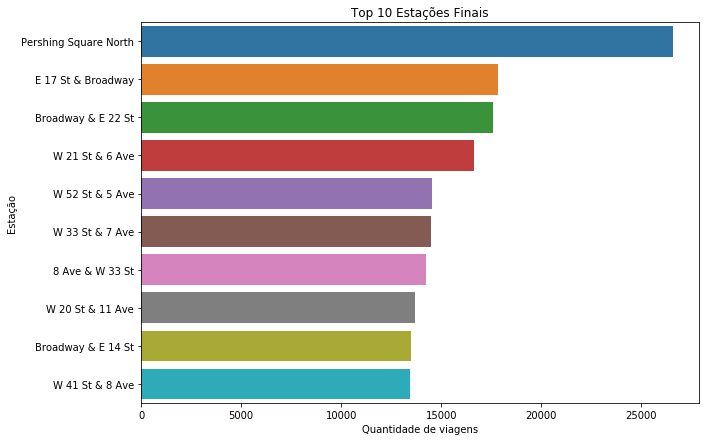

```python
#verifica quais as estação mais populares para finalizar as viagens
stop_station_top = df.groupby(['End Station Name']).size().reset_index(name='count').sort_values(by='count',ascending=False)
fig, ax = plt.subplots(figsize=(10,7))
sns.barplot(data=stop_station_top.head(10),y='End Station Name',x='count')
plt.ylabel('Estação')
plt.xlabel('Quantidade de viagens')
plt.title('Top 10 Estações Finais')
```

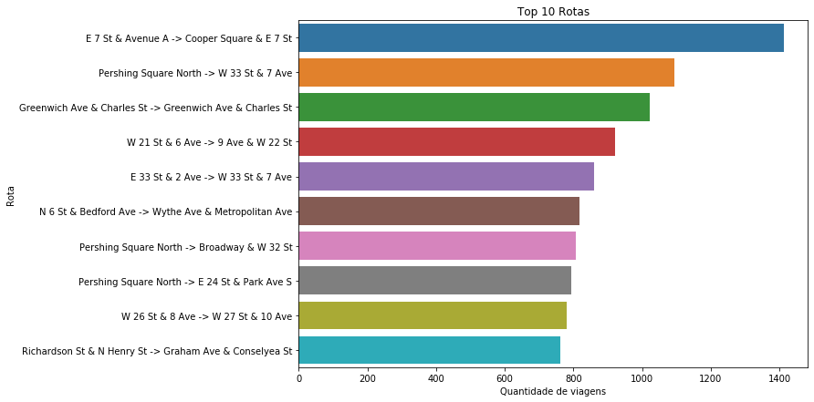

```python
top_routes = df.groupby(['Route']).size().reset_index(name='count').sort_values(by='count',ascending=False)
fig, ax = plt.subplots(figsize=(10,7))
sns.barplot(data=top_routes.head(10),y='Route',x='count')
plt.ylabel('Rota')
plt.xlabel('Quantidade de viagens')
plt.title('Top 10 Rotas')
```

A estação mais popular tanto para pegar as bicicletas quanto para deixa-las é a Pershing Square North, porém a rota mais realizada entre duas estação é da E 7 St & Avenue A para a Cooper Square & E 7 St.

```python
df_start_stations = df.groupby(['Start Station ID','Start Station Name','Start Station Latitude','Start Station Longitude']).size().reset_index(name='count')
df_stop_stations = df.groupby(['End Station ID','End Station Name','End Station Latitude','End Station Longitude']).size().reset_index(name='count')
df_start_stations.columns = ['Station ID','Station Name','Station Latitude','Station Longitude','Quantidade']
df_stop_stations.columns = ['Station ID','Station Name','Station Latitude','Station Longitude','Quantidade']
df_stations = pd.concat([df_start_stations,df_stop_stations],sort=False)
df_stations = df_stations.groupby(['Station ID','Station Name','Station Latitude','Station Longitude'])['Quantidade'].agg('sum').reset_index()
fig = px.scatter_mapbox(df_stations, lat="Station Latitude", lon="Station Longitude", hover_name="Station Name",
                       color_discrete_sequence=["fuchsia"], zoom=10, height=300,size='Quantidade',color='Quantidade')
fig.update_layout(mapbox_style="open-street-map")
fig.update_layout(margin={"r":0,"t":0,"l":0,"b":0})
fig.show()
```

[interactive chart not shown]

No mapa acima podemos ver que a distribuição das estações pela cidade é bem alta. Também podemos ver a quantidade de viagens realizadas em cada uma, quais são mais utilizadas e quais são menos.

# Conclusão

Para concluir a análise, enfatizo o fato de que as bicicletas já fazem parte do dia-a-dia das pessoas de Nova York. Como pudemos observar, a maior parte delas faz o uso das bicicletas para tarefas cotidianas como ir ao trabalho ou a escola, substituindo o uso de carros e outros meio de transporte, colaborando para o trânsito da cidade e para o meio ambiente. A quantidade de viagens já é extremamente alta assim como o número de estações espalhadas pela cidade, que tende a crescer cada vez mais, tornando o acesso as bicicletas cada vez mais fácil. Apesar da maioria das viagens serem curtas, tendo uma média de 11 minutos, ainda existem aqueles que se aventuram em viagens de 1 hora ou mais. Os dias úteis são mais movimentados que os fins de semana, porém, muitos utilizam as bicicletas aos sábados e domingos muito provavelmente para passeios e afazeres não cotidianos. Apesar da maioria dos usuários serem homens, a bicicleta se demonstrou extremamente democrática em relação a idade, sendo utilizada por todas as faixas etárias.